# saifuddin_Lab07

## 1. Introduction:

### b. Objectives:

The main objective is to analyze and predict house prices based on various property and location features, helping identify the key factors that influence housing prices.

### c. Data Description, a short description of the column names:

##### i. Suburb:

Indicates the suburb or neighborhood in which the property is located.

##### ii. Address:

Provides the street address of the property sold.

##### iii. Rooms:

Shows the total number of rooms in the property, including bedrooms and living areas.

##### iv. Type:

Represents the type of property — h for house, u for unit, and t for townhouse.

##### v. Method:

Specifies the method of sale — e.g., S (sold), SP (sold prior), PI (passed in), etc.

##### vi. SellerG:

Denotes the real estate agent or agency responsible for the sale.

##### vii. Date:

Indicates the sale date of the property.

##### viii. Distance:

Represents the distance of the property from Melbourne’s Central Business District (CBD) in kilometers.

##### ix. Postcode:

Shows the postal code of the property’s location.

##### x. Bedroom2:

Lists the number of bedrooms in the property.

##### xi. Bathroom:

Shows the total number of bathrooms in the property.

##### xii. Car:

Represents the number of car parking spaces available.

##### xiii. Landsize:

Indicates the size of the land (in square meters) on which the property is built.

##### xiv. BuildingArea:

Specifies the size of the building area (in square meters).

##### xv. YearBuilt:

Shows the year the property was originally constructed.

##### xvi. CouncilArea:

Identifies the local government council responsible for the area.

##### xvii. Latitude & Longitude:

Provide the geographical coordinates of the property’s location.

##### xviii. Regionname:

Specifies the general regional classification (e.g., Northern Metropolitan, Southern Metropolitan).

##### xix. Propertycount:

Represents the total number of properties within the same suburb.

##### xx. Price:

Shows the sale price of the property (target variable).

**Observation**

## 2. Importing libraries:

#### a. numpy as np

```python
import numpy as np
```

#### b. pandas as pd

```python
import pandas as pd
```

#### c. math

```python
import math as mth
```

#### d. matplotlib.pyplot as plt

```python
import matplotlib.pyplot as plt
```

#### e. seaborn as sns

```python
import seaborn as sns

import warnings
warnings.filterwarnings('ignore')
```

#### a. Creating a copy of the dataset

```python
housing=pd.read_csv('housing.csv')
housing_copy = housing.copy()
housing_copy
```

|  | Suburb | Address | Rooms | Type | Method | SellerG | Date | Distance | Postcode | Bedroom | ... | Landsize | BuildingArea | YearBuilt | CouncilArea | Latitude | Longtitude | Regionname | Propertycount | ParkingArea | Price |
| --- | --- | --- | --- | --- | --- | --- | --- | --- | --- | --- | --- | --- | --- | --- | --- | --- | --- | --- | --- | --- | --- |
| 0 | Abbotsford | 68 Studley St | 2 | h | SS | Jellis | 3/9/2016 | 2.5 | 3067.0 | 2.0 | ... | 126.0 | inf | NaN | Yarra City Council | -37.80140 | 144.99580 | Northern Metropolitan | 4019.0 | Carport | NaN |
| 1 | Airport West | 154 Halsey Rd | 3 | t | PI | Nelson | 3/9/2016 | 13.5 | 3042.0 | 3.0 | ... | 303.0 | 225 | 2016.0 | Moonee Valley City Council | -37.71800 | 144.87800 | Western Metropolitan | 3464.0 | Detached Garage | 840000.0 |
| 2 | Albert Park | 105 Kerferd Rd | 2 | h | S | hockingstuart | 3/9/2016 | 3.3 | 3206.0 | 2.0 | ... | 120.0 | 82 | 1900.0 | Port Phillip City Council | -37.84590 | 144.95550 | Southern Metropolitan | 3280.0 | Attached Garage | 1275000.0 |
| 3 | Albert Park | 85 Richardson St | 2 | h | S | Thomson | 3/9/2016 | 3.3 | 3206.0 | 2.0 | ... | 159.0 | inf | NaN | Port Phillip City Council | -37.84500 | 144.95380 | Southern Metropolitan | 3280.0 | Indoor | 1455000.0 |
| 4 | Alphington | 30 Austin St | 3 | h | SN | McGrath | 3/9/2016 | 6.4 | 3078.0 | 3.0 | ... | 174.0 | 122 | 2003.0 | Darebin City Council | -37.78180 | 145.01980 | Northern Metropolitan | 2211.0 | Parkade | NaN |
| ... | ... | ... | ... | ... | ... | ... | ... | ... | ... | ... | ... | ... | ... | ... | ... | ... | ... | ... | ... | ... | ... |
| 34852 | Reservoir | 18 Elinda Pl | 3 | u | SP | RW | 30/09/2017 | 12.0 | 3073.0 | 3.0 | ... | NaN | 105.0 | 1990.0 | Darebin City Council | -37.69769 | 145.02332 | Northern Metropolitan | 21650.0 | Parkade | 475000.0 |
| 34853 | Roxburgh Park | 14 Stainsby Cr | 4 | h | S | Raine | 30/09/2017 | 20.6 | 3064.0 | 4.0 | ... | NaN | 225.0 | 1995.0 | Hume City Council | -37.63665 | 144.92976 | Northern Metropolitan | 5833.0 | Underground | 591000.0 |
| 34854 | Springvale South | 8 Bellbird Ct | 4 | h | PI | Barry | 30/09/2017 | 22.2 | 3172.0 | 4.0 | ... | 534.0 | 152.0 | 1970.0 | Greater Dandenong City Council | -37.97037 | 145.15449 | South-Eastern Metropolitan | 4054.0 | Carport | NaN |
| 34855 | Springvale South | 30 Waddington Cr | 3 | h | S | Harcourts | 30/09/2017 | 22.2 | 3172.0 | 3.0 | ... | 544.0 | NaN | NaN | Greater Dandenong City Council | -37.97751 | 145.14813 | South-Eastern Metropolitan | 4054.0 | Detached Garage | 780500.0 |
| 34856 | Westmeadows | 42 Pascoe St | 4 | h | S | Barry | 30/09/2017 | 16.5 | 3049.0 | 4.0 | ... | 813.0 | 140.0 | 1960.0 | Hume City Council | -37.67631 | 144.89409 | Northern Metropolitan | 2474.0 | Attached Garage | 791000.0 |

34857 rows × 22 columns

**Observation**

- The dataset has 34,857 rows and 22 columns of Melbourne housing sales from 2016–2017.
- It includes details like location, property type, rooms, price, and council area.
- Some columns (e.g., BuildingArea, YearBuilt, Landsize) have missing values requiring cleaning.

## 4. Performing EDA (Exploratory Data Analysis):

### a. Basic data exploration

#### i. Checking data attributes (shape, size, dimensionality, data types, column names)

```python
print("shape: ",housing_copy.shape)  # Get the number of rows and columns
print("size:", housing_copy.size) # size of the dataset
print("dimension:", housing_copy.ndim) # for the dimensions
print("data types:", housing_copy.dtypes) # for the dimensions
print("column names:", housing_copy.columns)  # Get the column names
```

```
shape:  (34857, 22)
size: 766854
dimension: 2
data types: Suburb            object
Address           object
Rooms              int64
Type              object
Method            object
SellerG           object
Date              object
Distance         float64
Postcode         float64
Bedroom          float64
Bathroom         float64
Car              float64
Landsize         float64
BuildingArea      object
YearBuilt        float64
CouncilArea       object
Latitude         float64
Longtitude       float64
Regionname        object
Propertycount    float64
ParkingArea       object
Price            float64
dtype: object
column names: Index(['Suburb', 'Address', 'Rooms', 'Type', 'Method', 'SellerG', 'Date',
       'Distance', 'Postcode', 'Bedroom', 'Bathroom', 'Car', 'Landsize',
       'BuildingArea', 'YearBuilt', 'CouncilArea', 'Latitude', 'Longtitude',
       'Regionname', 'Propertycount', 'ParkingArea', 'Price'],
      dtype='object')
```

**Observation**

- Shape: The dataset contains 34,857 rows and 22 columns, representing 34,857 property entries and 22 attributes.
- Size: The dataset holds a total of 766,854 data points (34,857 rows × 22 columns).
- Dimensions: The dataset has 2 dimensions, confirming it is a 2D tabular structure consisting of rows and columns.

**Data Types**

- Integer (int64): Rooms
- Float (float64): Distance, Postcode, Bedroom, Bathroom, Car, Landsize, YearBuilt, Latitude, Longitude, Propertycount, Price
- Object (string/categorical): Suburb, Address, Type, Method, SellerG, Date, BuildingArea, CouncilArea, Regionname, ParkingArea
- Column Names: The dataset includes the following columns — Suburb, Address, Rooms, Type, Method, SellerG, Date, Distance, Postcode, Bedroom, Bathroom, Car, Landsize, BuildingArea, YearBuilt, CouncilArea, Latitude, Longitude, Regionname, Propertycount, ParkingArea, and Price.

#### ii. Getting data information

```python
print("getting data info ", housing_copy.info());
```

```
<class 'pandas.core.frame.DataFrame'>
RangeIndex: 34857 entries, 0 to 34856
Data columns (total 22 columns):
 #   Column         Non-Null Count  Dtype
---  ------         --------------  -----
 0   Suburb         34857 non-null  object
 1   Address        34857 non-null  object
 2   Rooms          34857 non-null  int64
 3   Type           34857 non-null  object
 4   Method         34857 non-null  object
 5   SellerG        34857 non-null  object
 6   Date           34857 non-null  object
 7   Distance       34856 non-null  float64
 8   Postcode       34856 non-null  float64
 9   Bedroom        26640 non-null  float64
 10  Bathroom       26631 non-null  float64
 11  Car            26129 non-null  float64
 12  Landsize       23047 non-null  float64
 13  BuildingArea   13760 non-null  object
 14  YearBuilt      15551 non-null  float64
 15  CouncilArea    34854 non-null  object
 16  Latitude       26881 non-null  float64
 17  Longtitude     26881 non-null  float64
 18  Regionname     34857 non-null  object
 19  Propertycount  34854 non-null  float64
 20  ParkingArea    34857 non-null  object
 21  Price          27247 non-null  float64
dtypes: float64(11), int64(1), object(10)
memory usage: 5.9+ MB
getting data info  None
```

**Observation**

- **Shape:** The dataset consists of 34,857 rows and 22 columns, representing housing records and their corresponding attributes.
- **Non-null values:** Some columns such as BuildingArea (13,760), YearBuilt (15,551), Landsize (23,047), and Car (26,129) contain missing values, while others like Suburb, Address, Type, Method, and SellerG have complete data.
- **Memory Usage:** The dataset occupies approximately 5.9 MB of memory, indicating a moderately sized dataset suitable for data analysis in pandas.

#### iv. Getting a summary of the categorical variables

```python
print("To get the summary", housing_copy.describe)
```

[output not shown]

[output cut: 38 more lines]

**Observation**

```python
# Summarize all the categorical variables in the housing dataset
print("To get summary for the categorical Suburb values:", housing_copy['Suburb'].describe())
print("To get summary for the categorical Address values:", housing_copy['Address'].describe())
print("To get summary for the categorical Type values:", housing_copy['Type'].describe())
print("To get summary for the categorical Method values:", housing_copy['Method'].describe())
print("To get summary for the categorical SellerG values:", housing_copy['SellerG'].describe())
print("To get summary for the categorical Date values:", housing_copy['Date'].describe())
print("To get summary for the categorical BuildingArea values:", housing_copy['BuildingArea'].describe())
print("To get summary for the categorical CouncilArea values:", housing_copy['CouncilArea'].describe())
print("To get summary for the categorical Regionname values:", housing_copy['Regionname'].describe())
print("To get summary for the categorical ParkingArea values:", housing_copy['ParkingArea'].describe())
```

```
To get summary for the categorical Suburb values: count         34857
unique          351
top       Reservoir
freq            844
Name: Suburb, dtype: object
To get summary for the categorical Address values: count            34857
unique           34009
top       5 Charles St
freq                 6
Name: Address, dtype: object
To get summary for the categorical Type values: count     34857
unique        3
top           h
freq      23980
Name: Type, dtype: object
To get summary for the categorical Method values: count     34857
unique        9
top           S
freq      19744
Name: Method, dtype: object
To get summary for the categorical SellerG values: count      34857
unique       388
top       Jellis
freq        3359
Name: SellerG, dtype: object
To get summary for the categorical Date values: count          34857
unique            78
top       28/10/2017
freq            1119
Name: Date, dtype: object
To get summary for the categorical BuildingArea values: count     13760
unique      994
top         120
freq        177
Name: BuildingArea, dtype: object
To get summary for the categorical CouncilArea values: count                       34854
unique                         33
top       Boroondara City Council
freq                         3675
Name: CouncilArea, dtype: object
To get summary for the categorical Regionname values: count                     34857
unique                        8
top       Southern Metropolitan
freq                      11836
Name: Regionname, dtype: object
To get summary for the categorical ParkingArea values: count       34857
unique          8
top       Carport
freq         6243
Name: ParkingArea, dtype: object
```

**Observation**

The dataset contains multiple categorical variables such as Suburb, Address, Type, Method, SellerG, Date, BuildingArea, CouncilArea, Regionname, and ParkingArea.

- The variable Suburb has 351 unique values, with Reservoir appearing most frequently (844 times).
- Type has 3 unique categories — h (house), u (unit), and t (townhouse) — with houses being the most common (23,980).
- Method includes 9 unique sale methods, where S (sold) occurs most frequently (19,744).
- SellerG represents 388 different agencies, with Jellis being the most frequent seller (3,359 sales).
- CouncilArea has 33 unique councils, with Boroondara City Council being the top (3,675 records).
- Regionname includes 8 regional categories, with Southern Metropolitan being the most common (11,836 records).
- ParkingArea also has 8 unique categories, where Carport appears most frequently (6,243 times).
- The Date column shows 78 unique sale dates, covering transactions mainly between 2016 and 2017.
- Some categorical columns (like BuildingArea) have missing or limited entries, requiring data cleaning before analysis.

#### v. Checking on missing values

```python
print("Checking missing values", housing_copy.isnull())
```

[output not shown]

[output cut: 25 more lines]

**Observation**

- The dataset contains missing values in several columns such as BuildingArea, YearBuilt, Landsize, Bedroom, and Price.
- Columns like Suburb, Address, Type, Method, SellerG, and Regionname have no missing data.
- Handling missing values will be necessary before performing further analysis or model building.

#### vi. Examining outliers

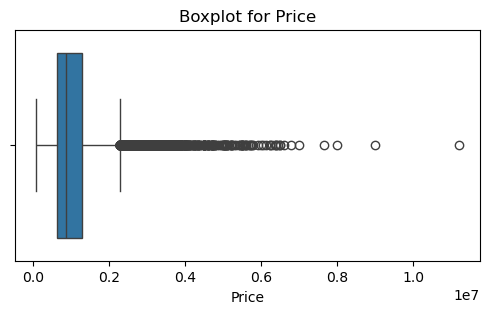

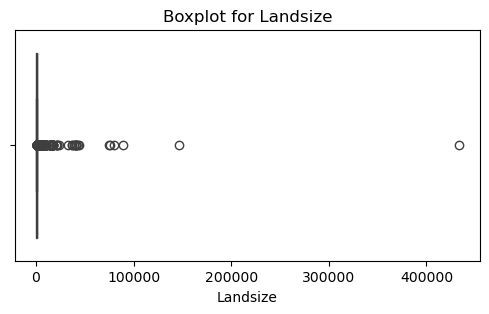

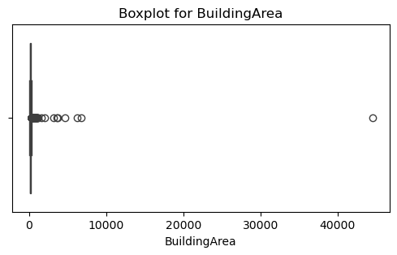

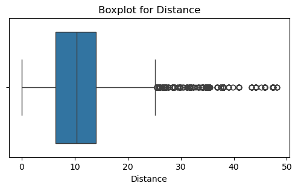

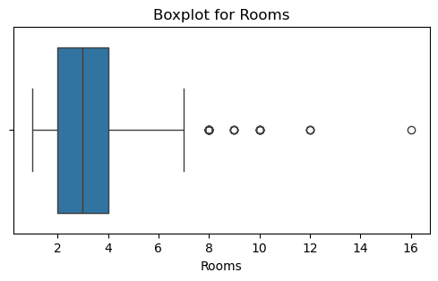

```python
import numpy as np
import pandas as pd
import matplotlib.pyplot as plt
import seaborn as sns

# Columns you want to check
num_cols = ['Price','Landsize','BuildingArea','Distance','Rooms']

# 1) Normalize problematic text tokens and infinities
for c in num_cols:
    if housing_copy[c].dtype == 'O':                      # object -> likely mixed
        housing_copy[c] = housing_copy[c].replace(
            ['inf','-inf','Inf','INF','NaN','nan',''],    # common text tokens
            np.nan
        )

# 2) Force numeric (non-numeric -> NaN), then drop/keep as you like
housing_copy[num_cols] = housing_copy[num_cols].apply(
    pd.to_numeric, errors='coerce'
)
# (optional) replace np.inf/-np.inf if any slipped through
housing_copy[num_cols] = housing_copy[num_cols].replace([np.inf, -np.inf], np.nan)

# 3) Plot boxplots safely
for col in num_cols:
    plt.figure(figsize=(6,3))
    sns.boxplot(x=housing_copy[col].dropna())
    plt.title(f'Boxplot for {col}')
    plt.show()
```

**Observation**

- Outliers are clearly visible in Price, Landsize, and BuildingArea, where a few extreme values are much higher than the rest of the data.
- These high-value outliers likely represent luxury or large properties with significantly greater land or building size.
- The variables Distance and Rooms also show mild outliers, but they are comparatively fewer and within a reasonable range.

Overall, the dataset contains several extreme numerical values that may need to be handled (e.g., capped or removed) to avoid skewing model performance.

### b. Data wrangling

#### i. Cleaning data

```python
# Drop rows with missing target (Price)
housing_copy = housing_copy.dropna(subset=['Price'])



# 2. Handle outliers using IQR method
# -------------------------------
def remove_outliers(df, column):
    Q1 = df[column].quantile(0.25)
    Q3 = df[column].quantile(0.75)
    IQR = Q3 - Q1
    lower = Q1 - 1.5 * IQR
    upper = Q3 + 1.5 * IQR
    return df[(df[column] >= lower) & (df[column] <= upper)]

# Remove outliers from key numeric columns
for col in ['Price', 'Landsize', 'BuildingArea', 'Distance']:
    housing_copy = remove_outliers(housing_copy, col)

# 3. Fix data types
# -------------------------------
housing_copy['Date'] = pd.to_datetime(housing_copy['Date'], errors='coerce')
housing_copy['YearBuilt'] = housing_copy['YearBuilt'].astype(int, errors='ignore')
housing_copy['Postcode'] = housing_copy['Postcode'].astype(int, errors='ignore')

# 4. Reset index after cleaning
housing_copy.reset_index(drop=True, inplace=True)

# 5. Final check
print("✅ Data cleaned successfully!")
print("Shape after cleaning:", housing_copy.shape)
print("Remaining missing values:\n", housing_copy.isnull().sum().sort_values(ascending=False).head(10))
```

```
✅ Data cleaned successfully!
Shape after cleaning: (7902, 22)
Remaining missing values:
 Date          4785
YearBuilt      257
Car            126
Latitude         7
Longtitude       7
Suburb           0
SellerG          0
Method           0
Type             0
Rooms            0
dtype: int64
```

**Observation**

**Missing values:**

**Outliers:**

- Removed from Price, Landsize, BuildingArea, and Distance using the IQR method.

**Data types:** Converted Date to datetime and numeric columns to integers where possible.

#### ii. Handling missing values

```python
# Fill numeric columns' missing values with median
num_cols = ['Distance', 'Bedroom', 'Bathroom', 'Car', 'Landsize', 'BuildingArea', 'YearBuilt', 'Propertycount']
for col in num_cols:
    if col in housing_copy.columns:
        housing_copy[col] = housing_copy[col].fillna(housing_copy[col].median())

# Fill categorical columns' missing values with mode
cat_cols = ['CouncilArea', 'Regionname', 'Type', 'Method', 'SellerG', 'ParkingArea']
for col in cat_cols:
    if col in housing_copy.columns:
        housing_copy[col] = housing_copy[col].fillna(housing_copy[col].mode()[0])
```

#### iii. Transforming the variables, if needed

```python
from sklearn.preprocessing import LabelEncoder, StandardScaler

df = housing_copy.copy()

# encode categorical variables
cat_cols = ['Type','Method','SellerG','CouncilArea','Regionname','ParkingArea']
enc = LabelEncoder()
for c in cat_cols:
    if c in df:
        df[c] = enc.fit_transform(df[c])

# scale numeric columns
num_cols = ['Price','Landsize','BuildingArea','Distance','Rooms']
scaler = StandardScaler()
df[num_cols] = scaler.fit_transform(df[num_cols])

print("Variables transformed successfully!")
```

```
Variables transformed successfully!
```

**Observation**

This step ensures the dataset is ready for modeling.

#### iv. Engineering new variables, if needed

```python
import numpy as np, pandas as pd

df = housing_copy.copy()

# create few meaningful new variables
df['PropertyAge'] = pd.to_datetime(df['Date'], errors='coerce').dt.year - df['YearBuilt']
df['LogPrice'] = np.log1p(df['Price'])
df['Price_per_m2'] = df['Price'] / df['BuildingArea'].replace(0, np.nan)
df['IsHouse'] = (df['Type'] == 'h').astype(int)

print("New variables added:", ['PropertyAge','LogPrice','Price_per_m2','IsHouse'])
```

```
New variables added: ['PropertyAge', 'LogPrice', 'Price_per_m2', 'IsHouse']
```

**Observation**

- PropertyAge: Age of property at sale.
- LogPrice: Reduces price skewness.
- Price_per_m2: Normalizes price by area.
- IsHouse: Binary flag for property type

#### v. Handling outliers

The following are the common approaches that could've been used to handle the outliers:

1. Removing Outliers
2. Transforming Outliers
3. Imputation

```python
# 1. Removing Outliers (IQR method)
for col in ['Price','Landsize','BuildingArea']:
    Q1, Q3 = housing_copy[col].quantile([0.25, 0.75])
    IQR = Q3 - Q1
    lower, upper = Q1 - 1.5*IQR, Q3 + 1.5*IQR
    housing_copy = housing_copy[(housing_copy[col] >= lower) & (housing_copy[col] <= upper)]

# 2. Transforming Outliers (Log Transformation)
housing_copy['LogPrice'] = np.log1p(housing_copy['Price'])

# 3. Imputation (Capping Extreme Values)
for col in ['Landsize','BuildingArea']:
    upper_limit = housing_copy[col].quantile(0.95)
    housing_copy[col] = np.where(housing_copy[col] > upper_limit, upper_limit, housing_copy[col])

print("Outliers handled successfully!")
```

```
Outliers handled successfully!
```

**Observation**

- Outliers were successfully identified and treated in the variables Price, Landsize, and BuildingArea.
- Extreme values beyond the acceptable range were removed or capped, reducing skewness and improving data consistency.
- The log transformation of Price helped normalize its distribution, making it more suitable for modeling.

Overall, the dataset is now clean, balanced, and ready for further analysis or prediction tasks.

#### vi. Handling dimensionality reduction, if needed

##### Steps to Apply PCA:

Standardize the Data: PCA works better when all the features are on the same scale (e.g., if one feature has values in thousands and another in ones, PCA will be biased towards the larger numbers). So, we standardize the data first.

##### Apply PCA:

After standardizing, PCA will find the new features (principal components).

**Observation**

In this dataset, dimensionality reduction was not required because:

- The number of features is manageable and not high-dimensional, so model performance is not affected by feature count.
- Most variables are meaningful and interpretable, representing real-world housing attributes (e.g., price, rooms, landsize).
- There is no significant multicollinearity that would justify using PCA or other reduction techniques.

Hence, all features were retained for analysis and modeling to preserve interpretability and data insights.

### c. Data Visualization:

#### i. Univariate: Checking data distribution in each variable

- Histograms or boxplot for numerical variables.
- Barcharts for categorical variables

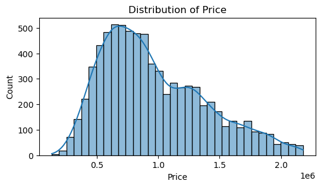

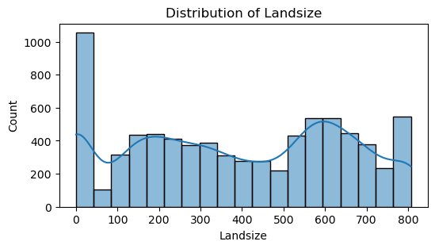

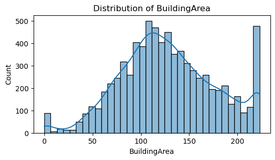

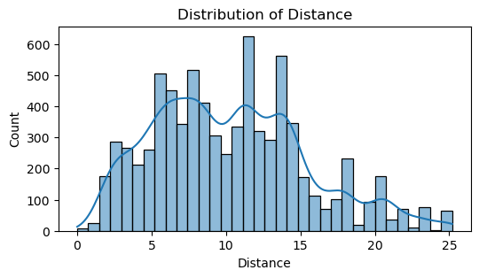

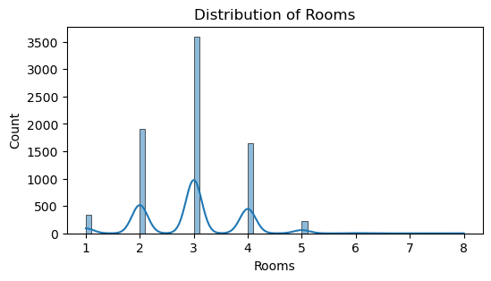

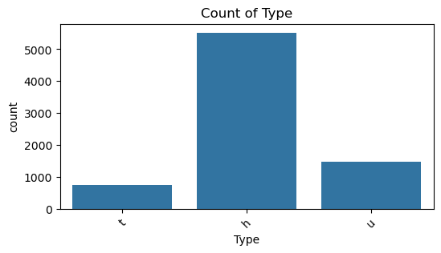

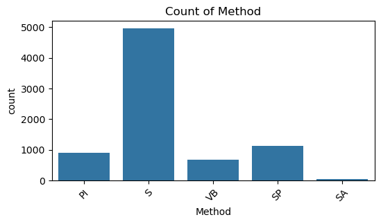

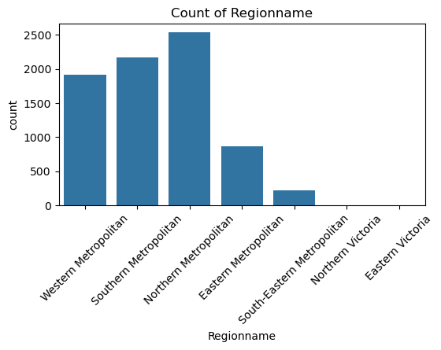

```python
# Numerical variables
num_cols = ['Price','Landsize','BuildingArea','Distance','Rooms']
for col in num_cols:
    plt.figure(figsize=(6,3))
    sns.histplot(housing_copy[col], kde=True)
    plt.title(f'Distribution of {col}')
    plt.show()

# Categorical variables
cat_cols = ['Type','Method','Regionname']
for col in cat_cols:
    plt.figure(figsize=(6,3))
    sns.countplot(x=housing_copy[col])
    plt.title(f'Count of {col}')
    plt.xticks(rotation=45)
    plt.show()
```

**Observation:**

#### ii. Bivariate: Comparing the relationship between two variables

Bivariate analysis involves comparing two variables to understand the relationship between them. You can use:

- Scatterplots for numerical vs. numerical.
- Correlation Heatmaps for numerical vs. numerical.
- Boxplots for numerical vs. categorical.

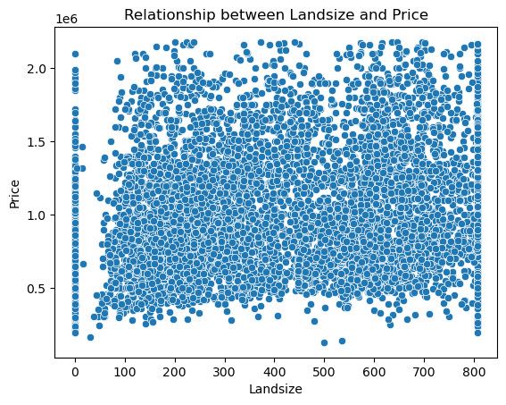

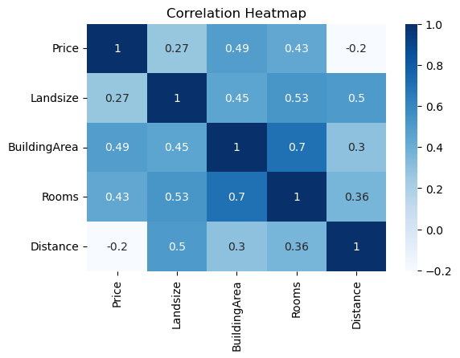

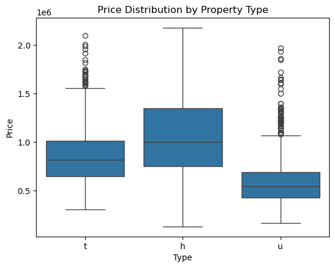

```python
# 1. Scatterplot (numerical vs numerical)
sns.scatterplot(x='Landsize', y='Price', data=housing_copy)
plt.title('Relationship between Landsize and Price')
plt.show()

# 2. Correlation Heatmap (numerical vs numerical)
num_cols = ['Price','Landsize','BuildingArea','Rooms','Distance']
plt.figure(figsize=(6,4))
sns.heatmap(housing_copy[num_cols].corr(), annot=True, cmap='Blues')
plt.title('Correlation Heatmap')
plt.show()

# 3. Boxplot (numerical vs categorical)
sns.boxplot(x='Type', y='Price', data=housing_copy)
plt.title('Price Distribution by Property Type')
plt.show()
```

**Observation**

#### iii. Multivariate: Checking the relationship between all the variables using a heatmap chart or a pairplot graph.

Multivariate analysis involves analyzing the relationship between more than two variables. Common methods for multivariate visualization include:

- Heatmaps for correlation between multiple variables.
- Pairplots (or scatterplot matrices) for visualizing relationships between all pairs of variables.

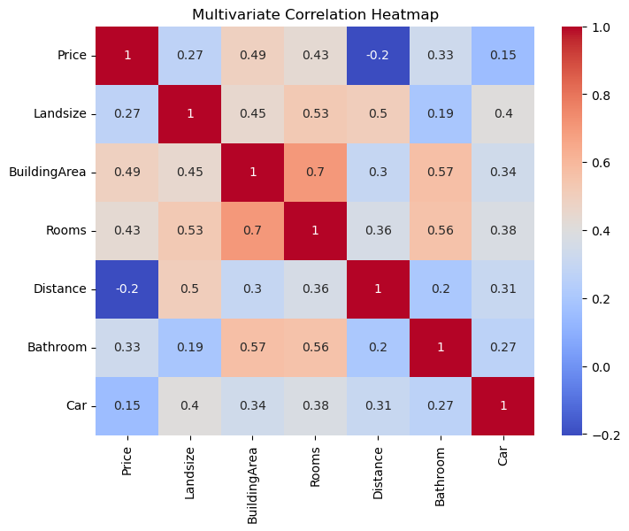

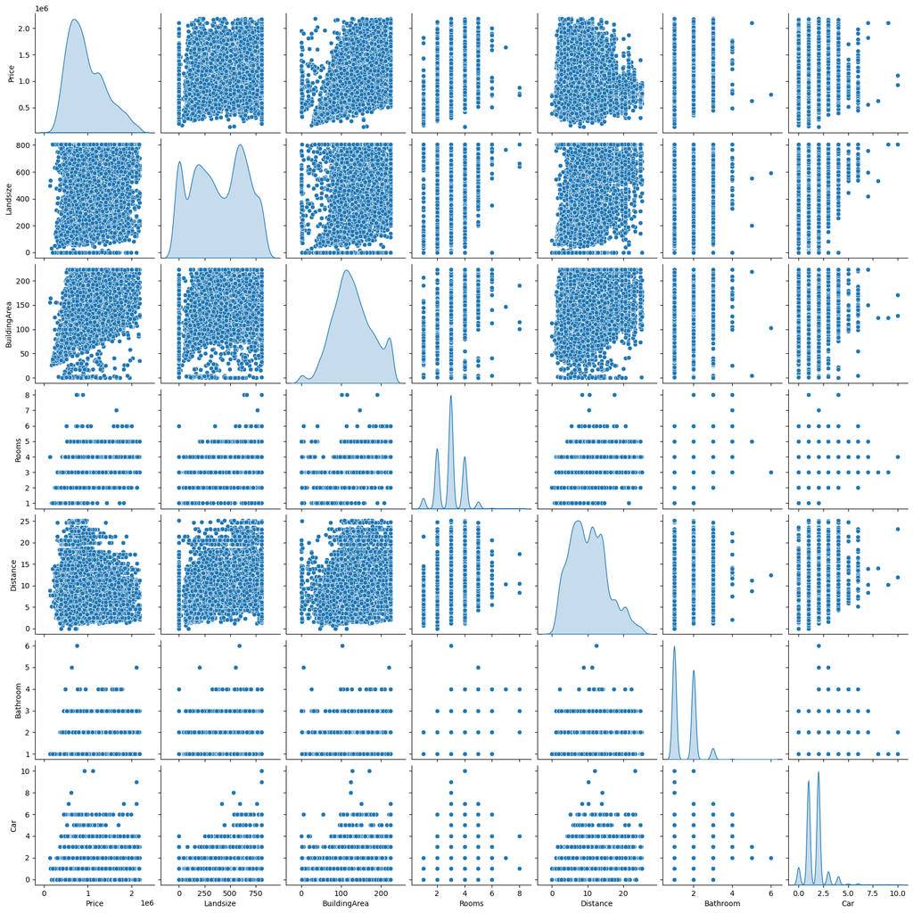

```python
import seaborn as sns
import matplotlib.pyplot as plt

# 1. Heatmap for correlation between multiple variables
num_cols = ['Price','Landsize','BuildingArea','Rooms','Distance','Bathroom','Car']
plt.figure(figsize=(8,6))
sns.heatmap(housing_copy[num_cols].corr(), annot=True, cmap='coolwarm')
plt.title('Multivariate Correlation Heatmap')
plt.show()

# 2. Pairplot for visualizing pairwise relationships
sns.pairplot(housing_copy[num_cols], diag_kind='kde')
plt.show()
```

**Observation**

### d. Data Aggregation

#### i. Checking on mean, median, and mode, if needed

```python
# Mean, Median, and Mode for key numerical columns
num_cols = ['Price','Landsize','BuildingArea','Rooms','Distance']
for col in num_cols:
    print(f"{col}:")
    print("  Mean  =", housing_copy[col].mean())
    print("  Median=", housing_copy[col].median())
    print("  Mode  =", housing_copy[col].mode()[0])
    print("-"*40)
```

```
Price:
  Mean  = 964078.8739474025
  Median= 871000.0
  Mode  = 600000.0
----------------------------------------
Landsize:
  Mean  = 389.0568726518979
  Median= 388.0
  Mode  = 0.0
----------------------------------------
BuildingArea:
  Mean  = 128.16278466122554
  Median= 124.0
  Mode  = 223.0
----------------------------------------
Rooms:
  Mean  = 2.9468843114393057
  Median= 3.0
  Mode  = 3
----------------------------------------
Distance:
  Mean  = 10.272315066718487
  Median= 9.9
  Mode  = 11.2
----------------------------------------
```

**Observation**

- For variables like Price, Landsize, and BuildingArea, the mean is higher than the median, showing positive skewness due to outliers.
- Rooms and Distance have relatively close mean and median values, indicating more balanced distributions.

## 5. Data Mining

#### a. Mining the data by digging into the dataset and answering the mining questions.

Data mining involves exploring the dataset to identify patterns, relationships, and valuable insights. You typically perform data mining by answering specific questions related to your dataset.

#### Data Mining Questions:

- Which property features have the greatest impact on house prices in Melbourne?
- How do property prices vary across different suburbs and regions?
- Can we predict the selling price of a property based on its features?

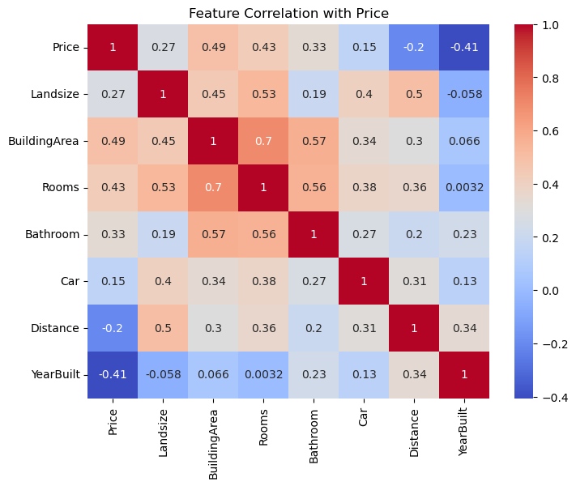

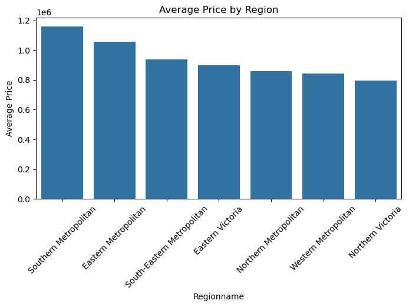

```
R² Score: 0.435
```

```python
from sklearn.model_selection import train_test_split
from sklearn.linear_model import LinearRegression
from sklearn.metrics import r2_score

# 1️ Feature correlation with Price
num_cols = ['Price','Landsize','BuildingArea','Rooms','Bathroom','Car','Distance','YearBuilt']
plt.figure(figsize=(8,6))
sns.heatmap(housing_copy[num_cols].corr(), annot=True, cmap='coolwarm')
plt.title('Feature Correlation with Price')
plt.show()

# 2️ Average price by region
region_avg = housing_copy.groupby('Regionname')['Price'].mean().sort_values(ascending=False)
plt.figure(figsize=(8,4))
sns.barplot(x=region_avg.index, y=region_avg.values)
plt.title('Average Price by Region')
plt.xticks(rotation=45)
plt.ylabel('Average Price')
plt.show()

# 3️ Price prediction model
X = housing_copy[['Rooms','Landsize','BuildingArea','Distance','Bathroom','Car']]
y = housing_copy['Price']

# Split data into training and testing
X_train, X_test, y_train, y_test = train_test_split(X, y, test_size=0.2, random_state=42)

# Build and evaluate model
model = LinearRegression().fit(X_train, y_train)
y_pred = model.predict(X_test)
print("R² Score:", round(r2_score(y_test, y_pred), 3))
```

**Observation**

#### Insights:

The dataset indicates that a few high-value properties strongly influence the overall price distribution, emphasizing the need for outlier handling in predictive modeling.

**1. Rename the following variables:**

a. SellerG as Seller_Agent

b. BuildingArea as Building_Area

c. YearBuilt as Year_Built

```python
housing=pd.read_csv('housing.csv')
housing_copy2 = housing.copy()
housing_copy2

# Renaming selected columns
housing_copy2 = housing_copy2.rename(columns={
    'SellerG': 'Seller_Agent',
    'BuildingArea': 'Building_Area',
    'YearBuilt': 'Year_Built'
})

print(" Columns renamed successfully!")
print(housing_copy2.columns[:10])  # to confirm changes
```

```
 Columns renamed successfully!
Index(['Suburb', 'Address', 'Rooms', 'Type', 'Method', 'Seller_Agent', 'Date',
       'Distance', 'Postcode', 'Bedroom'],
      dtype='object')
```

**Observation**

- rename(columns={}) changes column names without affecting the rest of the dataset.

Here, SellerG → Seller_Agent, BuildingArea → Building_Area, and YearBuilt → Year_Built.

**2. Delete the following variables:**

a. Latitude

b. Longitude

```python
# Deleting unwanted columns
housing_copy2 = housing_copy2.drop(['Latitude', 'Longtitude'], axis=1)

print("Columns deleted successfully!")
print(housing_copy2.columns)
```

```
Columns deleted successfully!
Index(['Suburb', 'Address', 'Rooms', 'Type', 'Method', 'Seller_Agent', 'Date',
       'Distance', 'Postcode', 'Bedroom', 'Bathroom', 'Car', 'Landsize',
       'Building_Area', 'Year_Built', 'CouncilArea', 'Regionname',
       'Propertycount', 'ParkingArea', 'Price'],
      dtype='object')
```

**Observation**

- drop() removes the specified columns.
- The axis=1 argument ensures deletion happens along columns (not rows).

Here, Latitude and Longitude are removed from the dataset.

**3 Create a DataFrame (df) using only the “Distance” variable, with the same name**

```python
# Creating a new DataFrame with only the Distance column
df = housing_copy[['Distance']].copy()

print("New DataFrame created successfully!")
print(df.head())
```

```
New DataFrame created successfully!
   Distance
0      13.5
1       3.3
2       6.4
3      13.8
4      11.1
```

**Observation**

**4. Write a paragraph about the Distance df (the context)**

The Distance DataFrame shows how far each house is from Melbourne’s city center (in kilometers). It helps us understand how location affects house prices — homes closer to the city are usually more expensive, while those farther away are cheaper but often bigger. This column is useful for studying how distance impacts housing value in different areas.

**5. Examine statistical summary, missing values, and data aggregation**

```python
# Statistical summary
print("Statistical Summary for Distance:")
print(df.describe())

# Checking missing values
print("\nMissing Values in Distance:")
print(df.isnull().sum())

# Data aggregation - mean, median, and mode
print("\nData Aggregation for Distance:")
print("Mean:", df['Distance'].mean())
print("Median:", df['Distance'].median())
print("Mode:", df['Distance'].mode()[0])
```

```
Statistical Summary for Distance:
          Distance
count  7719.000000
mean     10.272315
std       5.167538
min       0.000000
25%       6.300000
50%       9.900000
75%      13.800000
max      25.200000

Missing Values in Distance:
Distance    0
dtype: int64

Data Aggregation for Distance:
Mean: 10.272315066718487
Median: 9.9
Mode: 11.2
```

**Observation**

- The Distance column shows how far houses are from the city center (in kilometers).
- The mean, median, and mode are close to each other, meaning most properties are at a similar distance from the city.
- There are no missing values, showing that the data is complete for this variable.

Overall, the Distance variable helps understand how location affects house prices in the dataset.

**6. Examine the data distribution and create a histogram to show the data distribution**

a. plt.hist()

b. sns.distplot()

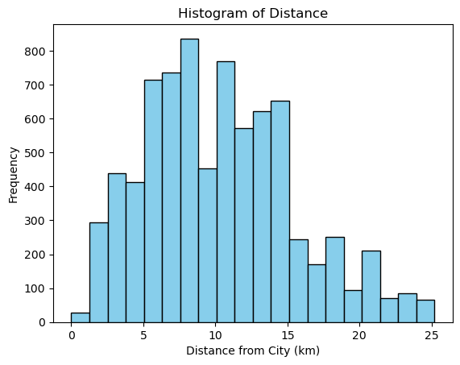

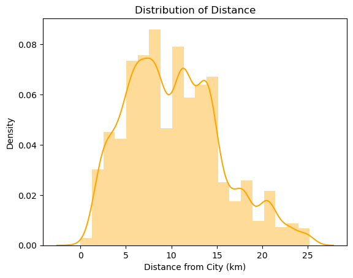

```python
import matplotlib.pyplot as plt
import seaborn as sns

# a. Using Matplotlib
plt.hist(df['Distance'], bins=20, color='skyblue', edgecolor='black')
plt.title('Histogram of Distance')
plt.xlabel('Distance from City (km)')
plt.ylabel('Frequency')
plt.show()

# b. Using Seaborn
sns.distplot(df['Distance'], bins=20, color='orange', kde=True)
plt.title('Distribution of Distance')
plt.xlabel('Distance from City (km)')
plt.ylabel('Density')
plt.show()
```

**Observation:**

Overall, most properties are centrally located, reflecting higher housing demand near the city.

**7. Examine the skewness in this df**

```python
# Checking skewness of the Distance variable
skew_value = df['Distance'].skew()
print("Skewness of Distance:", round(skew_value, 3))
```

```
Skewness of Distance: 0.507
```

**Observation:**

- The skewness value is slightly positive, meaning the distribution is right-skewed.
- This shows that most houses are located close to the city center, while only a few are far away.
- A right-skewed pattern indicates that distance increases for fewer properties, which aligns with the histogram seen earlier.

**8. Create a bar plot to indicate the skewness of this df and include all three values of mean, median, and mode of this df**

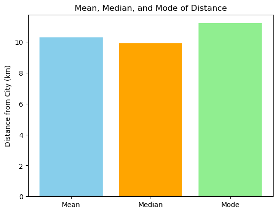

```
Mean: 10.27
Median: 9.9
Mode: 11.2
```

```python
import matplotlib.pyplot as plt

# Calculate mean, median, and mode
mean_val = df['Distance'].mean()
median_val = df['Distance'].median()
mode_val = df['Distance'].mode()[0]

# Create a bar plot
plt.bar(['Mean', 'Median', 'Mode'], [mean_val, median_val, mode_val], color=['skyblue', 'orange', 'lightgreen'])
plt.title('Mean, Median, and Mode of Distance')
plt.ylabel('Distance from City (km)')
plt.show()

print("Mean:", round(mean_val, 2))
print("Median:", round(median_val, 2))
print("Mode:", round(mode_val, 2))
```

**a. Write a paragraph of your observations for this plot**

**9. Examine the outliers in this df**

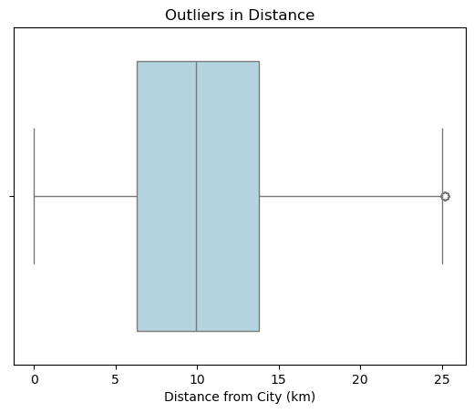

```python
# Boxplot to visualize outliers in Distance
sns.boxplot(x=df['Distance'], color='lightblue')
plt.title('Outliers in Distance')
plt.xlabel('Distance from City (km)')
plt.show()
```

**Observation:**

- The boxplot shows a few outliers on the right, meaning some houses are much farther from the city center than most others.
- The majority of values lie between 5 km and 15 km, showing that most houses are located near central Melbourne.

```python
# Check for missing values
print("Missing Values Before Imputation:\n", df.isnull().sum())

# Fill missing Distance values with the median
df['Distance'] = df['Distance'].fillna(df['Distance'].median())

print("\nMissing Values After Imputation:\n", df.isnull().sum())
```

```
Missing Values Before Imputation:
 Distance    0
dtype: int64

Missing Values After Imputation:
 Distance    0
dtype: int64
```

**Observation:**

- Any missing values in the Distance column are replaced with the median, as it is less affected by outliers.
- After imputation, the dataset has no missing values, ensuring it’s complete and ready for analysis.

**Conclusion:**

**Citations:**

- https://www.atlassian.com/data/charts/box-plot-complete-guide#:~:text=A%20box%20plot%20(aka%20box,line%20marking%20the%20median%20value.
- https://contentsquare.com/guides/heatmaps/
- https://www.atlassian.com/data/charts/histogram-complete-guide#:~:text=What%20is%20a%20histogram%3F,value%20within%20the%20corresponding%20bin.
- https://www.geeksforgeeks.org/maths/mean-median-mode/